# Descarga de plantilla y configuración de ambiente virtual

## Descarga e Instalación

Para instalar y ejecutar la plantilla a usar, en el caso práctico, en una terminal escribir:

```
conda activate <nombre_entorno_cookiecutter>
cookiecutter https://github.com/jvelezmagic/cookiecutter-conda-data-science
```

Durante la instalación de la plantilla y para que puedas reproducir el proyecto del profesor, elige las siguientes opciones:

```
Select project packages: Minimal
Python version: 3.9
```

## Activación

Para activar el proyecto, ejecutar lo siguiente en consola:

```
cd <nombre_carpeta_proyecto>
conda env create --file environment.yml
conda list python
code .
```

## Modulo del proyecto final

En este modulo aplicaremos todo lo aprendido en este curso,desde:

- Encontrar una plantilla,descargarla, instalarla y aplicarla para comenzar un nuevo proyecto desde cero.
- Crearemos un ambiente virtual para el proyecto y aprenderemos sobre el uso de notebooks para el trabajo conjunto con los scripts.

### Primer paso

Entramos a Git Hub, y en la barra de búsqueda colocamos `cookiecutter`, para buscar las plantillas que usaremos. En esta búsqueda encontramos uno interesante llamado [drivendata](https://github.com/drivendataorg/cookiecutter-data-science), es un plantilla muy popular entra la comunidad y ya está la `v2` disponible.

[figure not shown]

De momento usaremos la plantilla que el profesor ha creado [template cookiecutter](https://github.com/jvelezmagic/cookiecutter-conda-data-science), así con esta plantilla tomaremos la base y poco a poco necesitemos modificaciones o especificaciones diferentes, podemos añadirlo al template para ajustarlo a nuestras necesidades. Además esta plantilla ya contiene `conda`, cuenta con un manejador de rutas, ademas de contar con funciones para optimizar el uso de rutas.

### Descargando plantilla

Vayamos a la terminal y copiemos el siguiente enlace: `cookiecutter https://github.com/jvelezmagic/cookiecutter-conda-data-science`

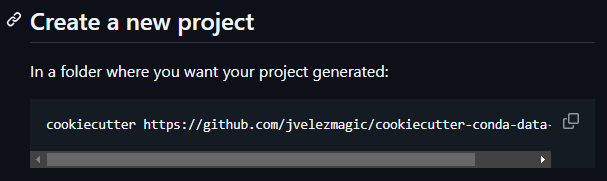

Abrimos VSCode y con el shortcut `Ctrl+Shift+P` abrimos una terminal, pegamos la instrucción. Ojo tenemos que estar en el ambiente de `cookiecutter` Una vez que lo hemos ejecutado nos aparece lo siguiente:

[figure not shown]

Se me ha creado mi carpeta de proyecto:

Entro al directorio y enlisto todo su contenido

[figure not shown]

Ahora nos encontramos con toda una estructura de proyecto dentro de final project, así ya tenemos todo lo necesario. ¿Qué sigue entonces?

### Instalar el ambiente

Ahora vamos a instalar el ambiente que contiene el archivo `environment.yml`. Con la siguiente instrucción ejecutamos el archivo environment.yml.

```
#Crear un ambiente
conda env create -f environment.yml
#Crear un ambiente
conda env create --file environment.yml
#Crearlo con Mamba
mamba env create --file environment.yml
#Mamba es mucho mas rápido que conda
```

Una vez que se ha creado me aparece un resumen del ambiente y como activarlo

[figure not shown]

Para activarlo damos:

```
#Activar el entorno
conda activate final_project
#checar version de python
python --version    #Me arroja la version 3.9.19
#Viendo que hemos descargado
code .
```

Me despliega todo lo que hemos descargado

[figure not shown]

Esta es la estructura inicial de nuestro proyecto de Ciencia de Datos.